# Rim Fire in Stanislaus National Forest, California

[figure not shown]

Aug 22, 2013 Image from MODIS  
[Jeff Schmaltz](https://upload.wikimedia.org/wikipedia/commons/thumb/4/47/Rim_Fire_and_American_Fire_large.jpg/256px-Rim_Fire_and_American_Fire_large.jpg), Public domain, via Wikimedia Commons

[figure not shown]

Rim Fire  
[US Gov](https://upload.wikimedia.org/wikipedia/commons/f/f3/The_Rim_Fire_in_the_Stanislaus_National_Forest_on_Aug._17%2C_2013_-001.jpg), Public domain, via Wikimedia Commons

### Site Description:

- The Rim Fire began in Stanislaus National Forest on August 17, 2013.
- 257,314 acres were affected.
- Most of the affected land was burned in the first week of the fire. The fire was fully contained by the end of October 2013 but not declared out until 2014.

For more information:

- https://www.esa.org/esablog/2014/08/05/the-rim-fire-one-year-later-a-natural-experiment-in-fire-ecology-and-management/
- https://storymaps.arcgis.com/stories/6b6b7ee6775b407595f6c91fa8bc1ecb

### Data Description:

- NDVI is an index comparing the reflection of red and near-infrared light; it allows for an assessment for the amount of healthy green vegetation on the ground. Higher NDVI values indicate more healthy vegetation.
- Data consists of MODIS NDVI values for the summer months from 2012 to 2023. As the fire began in mid-August 2013, the 2012 data represents the last year pre-fire. Summer 2014 data was the first full summer post-fire, since the fire began in mid-August 2013.
- The boundary for the fire was obtained from the National Interagency Fire Center.

### Map of Rim Fire

- A map of the affected area is below. The approximate starting location is shown, as well as vista for which the fire was named.

[interactive chart not shown]

### NDVI within the fire boundary has increased since the fire. However, it is yet to reach pre-fire levels ten years later.

- After the Rim Fire, NDVI in the area declined due to the loss of vegetation.
- Over the decade since the fire, NDVI has steadily increased. As of 2023, about two-thirds of the lost NDVI has been re-gained.

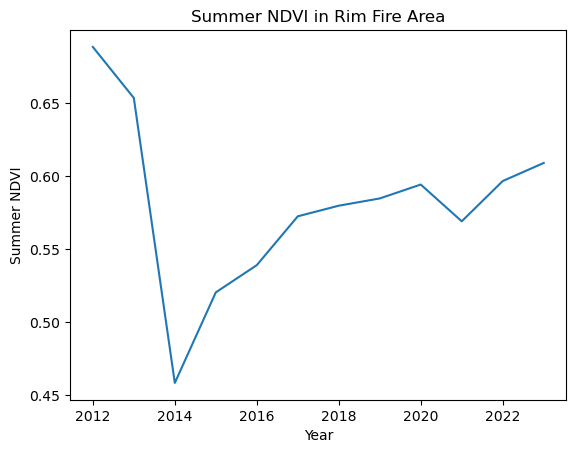

### NDVI in the affected area has returned to being higher than NDVI in surrounding areas, though not to the same extent.

- Prior to the 2013 Rim Fire, NDVI in the affected area was higher than in the surrounding areas, meaning this area had more healthy vegetation.
- After the fire, surrounding areas had higher NDVI and more healthy vegetation.
- As of 2023, NDVI in the area is once again higher than surrounding area though not to the extent it was pre-fire.

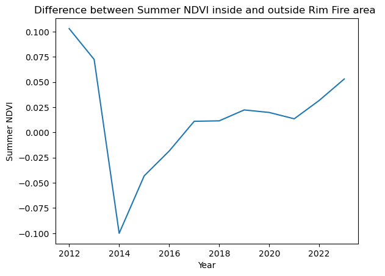

### Data Citations:

1. MODIS/Aqua Vegetation Indices 16-Day L3 Global 250m SIN Grid V061 [Data set]. NASA EOSDIS Land Processes Distributed Active Archive Center. Accessed 2023-10-04 from https://doi.org/10.5067/MODIS/MYD13Q1.061
2. Historic Geomac Perimeters All Years 2000 2018 gdb. National Interagency Fire Center. Accessed 2023-10-04 from https://data-nifc.opendata.arcgis.com/datasets/historic-geomac-perimeters-all-years-2000-2018-gdb/about